# Wind resource assessment

*Raynaldi Pratama*

01/03/2021

**Notes:** This portfolio shows several steps to perform the wind resource assessment according to the metocean historical data obtained from in-situ measurement recorded by the ocean buoy (Bilbao-Vizcaya) from 1990 to 2014.

**Library setup:**

```r
# Working with table
library(kableExtra)

# World map data from Natural Earth
library(rnaturalearth)
library(rnaturalearthdata)

# Data visualization
library(ggplot2)
library(ggspatial)

# Data manipulation
library(dplyr)

# Statistical function
library(MASS)
```

## Bilbao-Vizcaya buoy location

Bilbao-Vizcaya buoy has been chosen. The specific location should then be specified according to the correct coordinates on the map. It can be obtained through the Spanish authority web portal, [Puertos del Estado](http://www.puertos.es/en-us/oceanografia/Pages/portus.aspx).

### Load the spatial data

```r
spdf_world <- ne_countries(scale = "medium", returnclass = "sf")

class(spdf_world) # Spatial polygons df
```

```
## [1] "sf"         "data.frame"
```

```r
sldf_world <- ne_coastline(scale = "medium", returnclass = "sf")

class(sldf_world) # Spatial lines df
```

```
## [1] "sf"         "data.frame"
```

### Plot the corresponding data

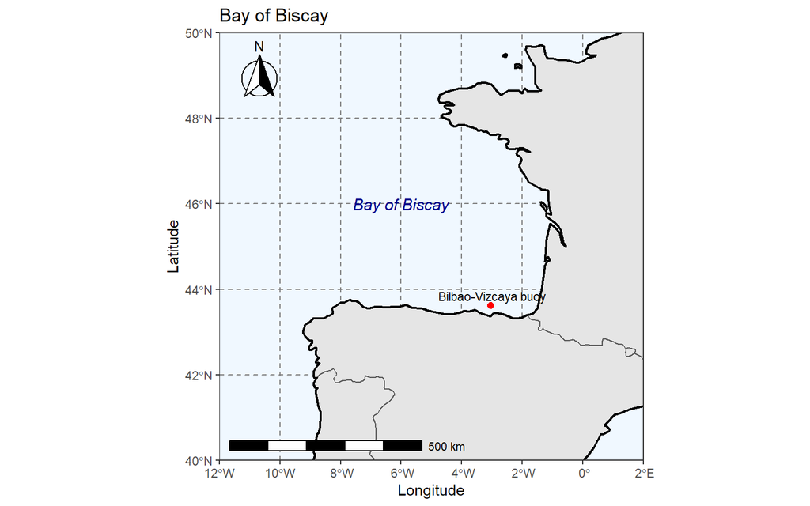

```r
theme_set(theme_bw()) # The classic dark-on-light theme works better in 'ggplot2' (optional)

ggplot() +
  geom_sf(data = spdf_world) +
  geom_sf(data = sldf_world, size = 0.75) +
  annotation_scale(width_hint = 0.5, location = "bl") +
  annotation_north_arrow(
    location = "tl",
    height = unit(1.5, "cm"),
    width = unit(1.5, "cm"),
    pad_x = unit(0.25, "cm"),
    pad_y = unit(0.25, "cm"),
    style = north_arrow_fancy_orienteering
  ) +
  annotate(
    geom = "text",
    x = -6,
    y = 46,
    label = "Bay of Biscay",
    fontface = "italic",
    color = "darkblue",
    size = 4
  ) +
  annotate(
    geom = "point",
    x = -3.04,
    y = 43.63,
    colour = "red",
    size = 2
  ) +
  annotate(
    geom = "text",
    x = -3,
    y = 43.85,
    label = "Bilbao-Vizcaya buoy",
    size = 3
  ) +
  coord_sf(xlim = c(-12, 2), ylim = c(40, 50), expand = FALSE) +
  theme(
    panel.grid.major = element_line(
      color = gray(0.5), linetype = "dashed", size = 0.5
    ),
    panel.background = element_rect(fill = "aliceblue")
  ) +
  xlab("Longitude") +
  ylab("Latitude") +
  ggtitle("Bay of Biscay")
```

## The average wind speed

In this section, we try to estimate the average wind speed at the hub height based on the wind recorded data from the 3 m reference height of the buoy. This approach is useful; suppose we plan to deploy the real offshore wind turbine (OWT) near the buoy location. In this case, an OWT of MWT-92/2.4 with 70 m hub height has been chosen. Another pre-determined condition: the terrain profile of ‘blown sea’ with the surface roughness length (approximated) value of 0.50 mm.

### Load the wind data

```r
buoydata <- read.table("BilbaoVizcaya.txt", header = TRUE) # Find the coresponding file inside 00_data/

buoydata <- buoydata %>%
  filter(buoydata$AA > "2009") # To obtain the best records and to avoid a whole-year missing data

kbl(summary(buoydata)) %>%
  kable_paper() %>%
  scroll_box(width = "100%", height = "300px")
```

|  | AA | MM | DD | HH | Hm0 | Tm02 | Tp | Hmax | Thmax | Pro_Oe | Dmd | Dmd_P | Ds_P | Pro_Od | Ts2 | Sa2 | Vc_md | Dc_md | Pro_Oce | Ps | Ta | Vv_md | Dv_md | Pro_Met | Qc_e |
| --- | --- | --- | --- | --- | --- | --- | --- | --- | --- | --- | --- | --- | --- | --- | --- | --- | --- | --- | --- | --- | --- | --- | --- | --- | --- |
|  | Min. :2010 | Min. : 1.000 | Min. : 1.00 | Min. : 0.00 | Min. : 0.000 | Min. : 2.600 | Min. : 0.000 | Min. : 0.000 | Min. : 0.00 | Min. :1.000 | Min. : 0.0 | Min. : 0.0 | Min. :10.00 | Min. :1.000 | Length:39916 | Length:39916 | Length:39916 | Length:39916 | Min. :2.000 | Min. : 976 | Min. : 2.20 | Min. : 0.000 | Min. : 0.0 | Min. :2.000 | Min. :1.000 |
|  | 1st Qu.:2011 | 1st Qu.: 4.000 | 1st Qu.: 8.00 | 1st Qu.: 5.75 | 1st Qu.: 1.000 | 1st Qu.: 4.700 | 1st Qu.: 7.700 | 1st Qu.: 1.600 | 1st Qu.: 7.20 | 1st Qu.:1.000 | 1st Qu.:295.0 | 1st Qu.:295.0 | 1st Qu.:23.00 | 1st Qu.:1.000 | Class :character | Class :character | Class :character | Class :character | 1st Qu.:2.000 | 1st Qu.:1012 | 1st Qu.:12.50 | 1st Qu.: 2.500 | 1st Qu.: 90.0 | 1st Qu.:2.000 | 1st Qu.:1.000 |
|  | Median :2012 | Median : 6.000 | Median :16.00 | Median :12.00 | Median : 1.600 | Median : 5.700 | Median : 9.600 | Median : 2.400 | Median : 9.20 | Median :1.000 | Median :307.0 | Median :305.0 | Median :28.00 | Median :1.000 | Mode :character | Mode :character | Mode :character | Mode :character | Median :2.000 | Median :1017 | Median :15.80 | Median : 4.400 | Median :202.0 | Median :2.000 | Median :1.000 |
|  | Mean :2012 | Mean : 6.467 | Mean :15.67 | Mean :11.50 | Mean : 1.843 | Mean : 5.902 | Mean : 9.449 | Mean : 2.849 | Mean : 9.16 | Mean :1.133 | Mean :288.6 | Mean :290.9 | Mean :29.28 | Mean :1.133 | NA | NA | NA | NA | Mean :2.064 | Mean :1016 | Mean :15.69 | Mean : 4.874 | Mean :191.5 | Mean :2.064 | Mean :1.042 |
|  | 3rd Qu.:2013 | 3rd Qu.: 9.000 | 3rd Qu.:23.00 | 3rd Qu.:17.00 | 3rd Qu.: 2.300 | 3rd Qu.: 6.900 | 3rd Qu.:11.100 | 3rd Qu.: 3.500 | 3rd Qu.:11.00 | 3rd Qu.:1.000 | 3rd Qu.:319.0 | 3rd Qu.:316.0 | 3rd Qu.:34.00 | 3rd Qu.:1.000 | NA | NA | NA | NA | 3rd Qu.:2.000 | 3rd Qu.:1021 | 3rd Qu.:19.30 | 3rd Qu.: 6.700 | 3rd Qu.:286.0 | 3rd Qu.:2.000 | 3rd Qu.:1.000 |
|  | Max. :2014 | Max. :12.000 | Max. :31.00 | Max. :23.00 | Max. :10.100 | Max. :13.600 | Max. :22.300 | Max. :16.100 | Max. :22.40 | Max. :3.000 | Max. :360.0 | Max. :360.0 | Max. :79.00 | Max. :3.000 | NA | NA | NA | NA | Max. :3.000 | Max. :1038 | Max. :27.30 | Max. :19.600 | Max. :357.0 | Max. :3.000 | Max. :9.000 |
|  | NA | NA | NA | NA | NA’s :59 | NA’s :61 | NA’s :59 | NA’s :2741 | NA’s :2741 | NA | NA’s :1475 | NA’s :59 | NA’s :2743 | NA | NA | NA | NA | NA | NA | NA’s :4442 | NA’s :2 | NA’s :91 | NA’s :5996 | NA | NA |

### Replace NA values

At this point, we may notice that the buoy dataset contains many of NA’s value, including the particular observation of the wind speed ‘Vv_md’ column we need to handle. One way to take care of these NA’s value is by omitting them using **`na.omit()`**. For this typical dataset, only eliminating the NA’s data will give a much different result since each category’s total observation is related to one another. Thus, replacing NA’s with the proper value, e.g., the average or median of the recorded data, has to be considered.

However, as the analysis continues, another uncommon data distribution situation might arise, such as the presence of a considerable amount of outliers after imputing different value to NA’s. We, therefore, may also need to take off these outliers the same way as we have done with NA’s value. Alternatively, instead of replacing with the average or median of the data, we can introduce random value generated using [the uniform distribution funtion](https://www.rdocumentation.org/packages/stats/versions/3.6.2/topics/Uniform), **`runif()`**. The arguments should be put correctly according to the summary of the recorded data, i.e., the total of NA’s, minimum and maximum value.

Note that this method might not be valid nor could be applied to all datasets. The results would also be varied (with small differences) every time we run the script since we put random numbers in the analysis. Yet, to satisfy the final result, it is worth trying; thus, some comparisons and trial and error are needed along the way to fit the data.

Additionally, the **`na_if`** function can be accessed through **`dplyr`** package, which, in this section, is used to change “NAN” with “NA” so that R will be able to read such data.

```r
windSpeed <- na_if(buoydata$Vv_md, "NAN")

windSpeed[is.na(windSpeed)] <- mean(windSpeed, na.rm = TRUE)

summary(windSpeed)
```

```
##    Min. 1st Qu.  Median    Mean 3rd Qu.    Max.
##   0.000   2.500   4.400   4.874   6.700  19.600
```

### Transform $U$ to 70 m height

To estimate the wind speed at 70 m hub height, we may use the equation based on the Logarithmic Law, which written as follows:

$$\frac{U(z)}{U(z_r)} = \frac{ln(\frac{z}{z_0})}{ln(\frac{z_r}{z_0})}$$

Where, $U$ = Wind speed (m/s); $z_0$ = Surface roughness length (approximated) value (m); $z_r$ = Reference height (m).

```r
windSpeed70 <- windSpeed * log(70 / 0.0005) / log(3 / 0.0005)

summary(windSpeed70)
```

```
##    Min. 1st Qu.  Median    Mean 3rd Qu.    Max.
##   0.000   3.405   5.993   6.639   9.126  26.697
```

## Weibull distribution fit

The wind speed data likely follows the Weibull or Rayleigh probability density function, quoted in many literature sources from the historical records. It can also be observed from the resulting histogram that fits the pattern of either distribution.

### Get Weibull parameters

To get the shape (k) and scale (c) parameter of Weibull distribution according to the data, we can use **`fitdistr`** function from **`MASS`** package. The usage of this function is explained [in this link](https://www.rdocumentation.org/packages/MASS/versions/7.3-50/topics/fitdistr). Furthermore, the explanation of extracting model coefficients using **`coef()`** can be found [in this link](https://www.rdocumentation.org/packages/stats/versions/3.6.2/topics/coef).

```r
windSpeed70[windSpeed70 == 0] <- 0.0001 # Weibull values must be > 0

summary(windSpeed70)
```

```
##    Min. 1st Qu.  Median    Mean 3rd Qu.    Max.
##  0.0001  3.4052  5.9931  6.6393  9.1259 26.6967
```

```r
k <- coef(
  fitdistr(windSpeed70, "weibull")
)[1] # Shape parameter

k
```

```
##   shape
## 1.43398
```

```r
c <- coef(
  fitdistr(windSpeed70, "weibull")
)[2] # Scale parameter

c
```

```
##    scale
## 7.189642
```

The average wind speed may also be estimated considering both parameters k and c are known using the following equation.

$$\overline{U} = c*\Gamma(1 + \frac{1}{k})$$

Where, $\overline{U}$ = Average wind speed (m/s); $\Gamma(x)$ = Gamma function = $\int_0^\infty e^{-t} t^{x - 1} dt$.

### Plot wind data histogram

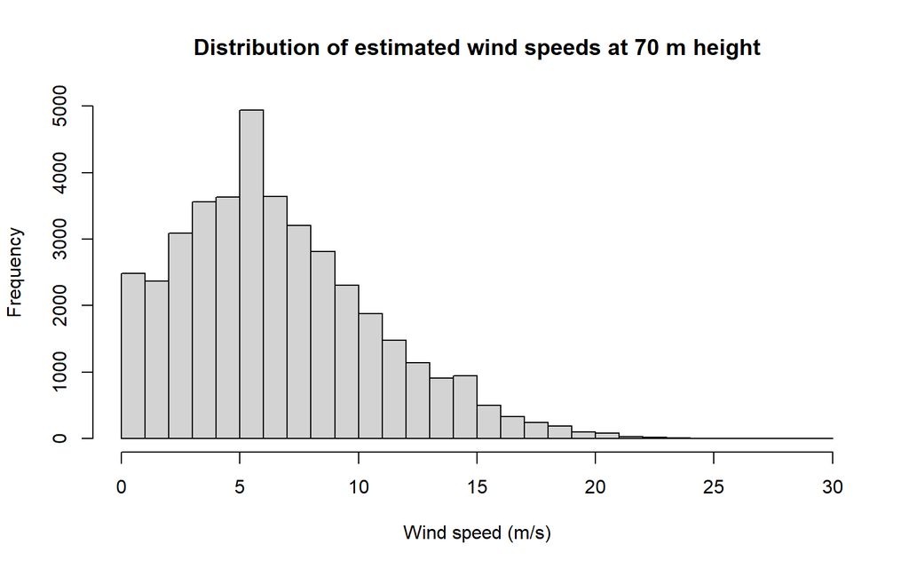

```r
qVector <- seq(0, 30, 1) # Vector of quantiles

weibulldistr <- dweibull(qVector, k, c)

histogram <- hist(windSpeed70,
  qVector,
  main = "Distribution of estimated wind speeds at 70 m height",
  xlab = "Wind speed (m/s)",
  ylim = c(0, 5000)
)
```

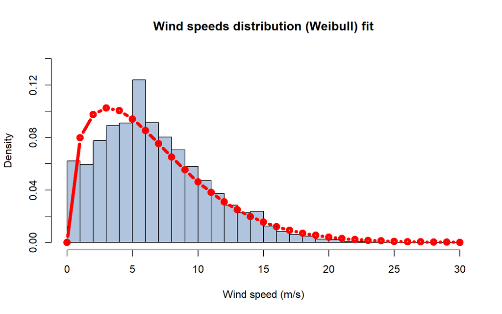

```r
plot(histogram,
  freq = FALSE,
  col = "lightsteelblue",
  main = "Wind speeds distribution (Weibull) fit",
  xlab = "Wind speed (m/s)",
  ylim = c(0, 0.14)
)

lines(qVector, weibulldistr, type = "b", lwd = 5, col = "red")
```

### Get the turbine’s working hours

Now that we have obtained the Weibull distribution shape and scale parameters, by using the cumulative distribution function (frequency of occurrence below U), we can estimate the annual working hours between the cut-in and cut-out speed of OWT. The cut-in and cut-out speeds are 3 m/s and 25 m/s, respectively, and the cumulative distribution function is written as follows:

$$F(U) = 1 - exp[ -(\frac{U}{c})^k]$$

```r
F3 <- 1 - exp(-((3 / c)^k))

F25 <- 1 - exp(-((25 / c)^k))

workinghrs <- (F25 - F3) * 365 * 24 # Considering 365 days per year

workinghrs
```

```
##    scale
## 6561.695
```

## Initial AEP and CF

Below are the steps of estimating the initial value of the annual energy production (AEP) and capacity factor (CF) of OWT without considering the turbine’s power curve. AEP can be calculated using the following equation:

$$AEP = eff * 0.5 * \rho * A * c^3 * \Gamma(1 + \frac{3}{k}) * (365.25 * 24)$$

### Specify turbine’s parameters

```r
eff <- 0.4

R <- 92 / 2

A <- pi * R^2
```

### Inspect air pressure data

```r
Ps <- na_if(buoydata$Ps, "NAN")

Ps[is.na(Ps)] <- mean(Ps, na.rm = TRUE)

Ps <- Ps * 10^2 # Pressure unit conversion from mbar to Pa

summary(Ps)
```

```
##    Min. 1st Qu.  Median    Mean 3rd Qu.    Max.
##   97600  101300  101647  101647  102100  103800
```

### Inspect air temperature data

```r
Ta <- na_if(buoydata$Ta, "NAN")

Ta[is.na(Ta)] <- mean(Ta, na.rm = TRUE)

Ta <- Ta + 273 # Temperature unit conversion from Celcius to Kelvin

summary(Ta)
```

```
##    Min. 1st Qu.  Median    Mean 3rd Qu.    Max.
##   275.2   285.5   288.8   288.7   292.3   300.3
```

### Calculate the initial AEP

```r
rho <- Ps / (287.058 * Ta) # Air density in kg/m^3

AEP0 <- eff * 0.5 * mean(rho) * A * c^3 * gamma(1 + (3 / k)) * (365 * 24)

(AEP0 <- AEP0 * 10^-9) # AEP unit conversion from Wh to GWh
```

```
##    scale
## 11.58134
```

### Calculate the initial CF

```r
CF0 <- AEP0 / (2.4 * (365 * 24) * 10^-3)

CF0
```

```
##    scale
## 0.550863
```

The result above shows that the initial AEP and CF are considered relatively high for the typical wind turbine. Thus, the power curve needs to be taken into consideration while calculating the more realistic value of AEP and CF.

## Wind power density

The wind power density can be estimated using the equation below:

$$\frac{P}{A} = 0.5 * \rho * U^3$$

Where, $P / A$ = Wind power density (W/m<sup>2</sup>) with the following classification:

- $\overline{P} / A < 100$ W/m<sup>2</sup> - low
- $\overline{P} / A \approx 400$ W/m<sup>2</sup> - good
- $\overline{P} / A > 700$ W/m<sup>2</sup> - great

### Plot the monhtly air density

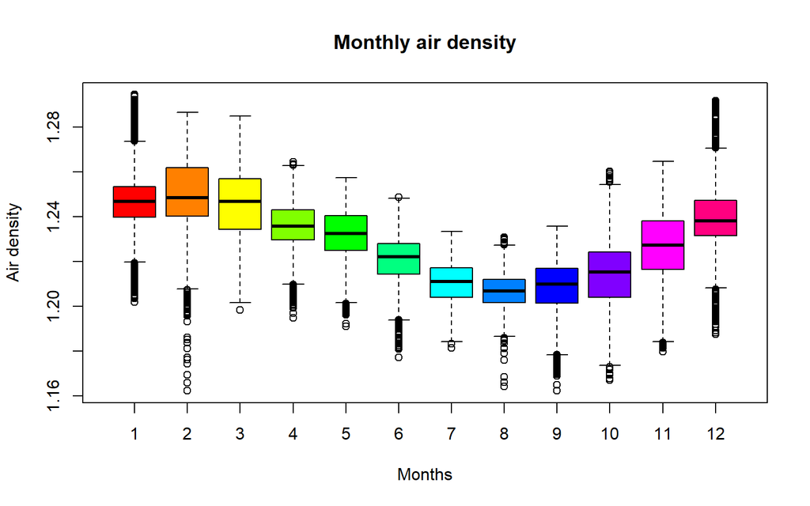

```r
monthlyAirDensity <- cbind(buoydata[, 1:4], rho)

boxplot(monthlyAirDensity[, 5] ~ monthlyAirDensity[, 2],
  col = rainbow(12),
  xlab = "Months",
  ylab = "Air density"
)

title("Monthly air density")
```

### Calculate wind power density

```r
WPD <- 0.5 * rho * (windSpeed70^3)

summary(WPD)
```

```
##     Min.  1st Qu.   Median     Mean  3rd Qu.     Max.
##     0.00    24.56   134.55   419.52   461.72 11294.86
```

## Actual AEP and CF

In this part, the actual annual energy production (AEP) and capacity factor (CF) is calculated by introducing the OWT’s power curve data. Hence, to fit the wind speed data, represented by the histogram and the power curve, both datasets’ lengths need to be adjusted. It is known that the size of the histogram density is 30, and the size of the power curve data is 25. Therefore, the extra elements (5 elements) of the power curve have to be added to match the histogram density length. As a result, the power curve observation will then have as many as 30 elements. Up to this point, We should also consider that the cut-off speed of the OWT is 25 m/s. It means that the wind turbine will not produce the energy as the wind speed goes above 25 m/s; thus, the power generated following the remaining wind speeds will be 0.

Additionally, the extra elements for the power curve data are added using **`rep()`** function. The documentation of this function can be accessed through [this link](https://www.rdocumentation.org/packages/base/versions/3.6.2/topics/rep).

### Incorporate the power curve data

```r
PC <- read.table("PC_MWT92-2.4.txt", header = TRUE) # Wind turbine power curve

density <- histogram$density # Sum of pdf must be equal to 1

ntimes <- length(density) - nrow(PC) # as a second argument in rep() to add extra elements (as many as n-times) in PC

dataPC <- c(PC[, 2], rep(0, ntimes)) # Size of dataPC equals to length of density: 30 elements

dataPC
```

```
##  [1]    0    0   15   53  171  341  577  889 1283 1731 2117 2342 2400 2400 2400
## [16] 2400 2400 2400 2400 2400 2400 2400 2400 2400 2400    0    0    0    0    0
```

### Calculate the actual AEP

```r
AEP <- sum(density * dataPC) * (365 * 24) * 10^-6

AEP
```

```
## [1] 7.318569
```

### Calculate the actual CF

Another method to calculate the capacity factor (CF) is proposed by Masters, 2004, which is presented as follows:

$$CF = 0.087 * \overline{U} - \frac{P_R}{D^2}$$

```r
CF1 <- AEP / (2400 * 10^-6 * (365.25 * 24))

CF1 # Upper limit
```

```
## [1] 0.3478672
```

```r
CF2 <- 0.087 * mean(windSpeed70) - (2400 / 92^2)

CF2 # Lower limit
```

```
## [1] 0.2940635
```

As the results, by introducing the power curve, the more realistic AEP for a single wind turbine in such area is obtained with $\approx 7.32$ GWh. Simultaneously, the suggested lower and upper limit of CF are 0.294 and 0.348, respectively.